# Reglas de asociación - trabajo final

Maria Lucia Guastoni

13/5/2021

# 1. Introducción

En el presente trabajo se analizan diferentes reglas de asociación.

El objetivo de las reglas de asociación es encontrar relaciones entre productos dentro de un conjunto de transacciones, en este caso en particular, en un libro de recetas. Concretamente, lo que se busca es determinar qué items ocurren de manera conjunta.

Es necesario para el análisis, definir algunos conceptos esenciales:

- Soporte: el soporte de un item o un conjunto de items (itemsets) es la porcentaje de transacciones, recetas en este caso, que contienen al item o itemset con respecto a la totalidad de recetas

$$s(A \rightarrow B) = \frac{\sigma(A,B)}{|T|} = P(A \cup B)$$

- Confianza: es la probabilidad de que una receta que contiene ciertos items, también contenga otros ciertos items

$$c(A \rightarrow B) = \frac{s(A \rightarrow B)}{s(A)} = \frac{P(A \cup B)}{P(A)}$$

El proceso de encontrar reglas de asociación consiste en dos pasos: en primer lugar, se deben identificar los itemsets frecuentes, es decir, aquellos que superan el soporte mínimo, que tienen una cierta frecuencia. En el segundo paso se generan las reglas de asociación propiamente dichas, donde se busca generar reglas con una confianza alta a partir del conjunto de elementos frecuentes identificados en el paso anterior.

# 2. Carga de los datos

Se comienza por cargar los datos y obtener algunas medidas de resumen de los mismos:

```r
data <- read.transactions("recetas_limpias_1.csv", sep=",", header = F)
summary(data)
```

```
transactions as itemMatrix in sparse format with
 1489 rows (elements/itemsets/transactions) and
 3463 columns (items) and a density of 0.002275809

most frequent items:
   salt   sugar  butter   flour   water (Other)
    581     385     283     211     206   10069

element (itemset/transaction) length distribution:
sizes
  0   1   2   3   4   5   6   7   8   9  10  11  12  13  14  15  16  17  18  19
 13  21  53  72 106 133 189 173 146 140 106  87  67  66  41  31  19   7   7   4
 20  21  22  24  27  31
  2   1   2   1   1   1

   Min. 1st Qu.  Median    Mean 3rd Qu.    Max.
  0.000   5.000   7.000   7.881  10.000  31.000

includes extended item information - examples:
                  labels
1           acorn squash
2 across bone inch thick
3         acrylic paints
```

```r
inspect(data[1:3,])
```

```
    items
[1] {apples,
     lemons,
     oranges,
     saladitos}
[2] {basil,
     cloves garlic,
     corn,
     favorite seasonings,
     hamburger,
     italian seasoning,
     kidney beans,
     mild,
     mushrooms,
     onion,
     tomato sauce,
     uncooked pasta}
[3] {beef bouillon cubes,
     beer,
     chili powder,
     cloves garlic,
     cumin,
     ground pork,
     lean beef brisket,
     mustard,
     onions,
     oregano,
     salt,
     tequila,
     tomato sauce,
     tomatoes}
```

El listado ampliado de los ingredientes más frecuentes es:

```
# A tibble: 15 x 2
   V1            count
   <chr>         <int>
 1 salt            581
 2 sugar           385
 3 butter          283
 4 flour           211
 5 water           206
 6 eggs            191
 7 milk            189
 8 onion           177
 9 olive           134
10 purpose flour   106
11 baking powder   101
12 brown sugar      94
13 cinnamon         82
14 cloves garlic    77
15 vanilla          71
```

# 3. Paso 1: Itemsets frecuentes

Para calcular los itemsets frecuentes se utilizará la función `eclat`. Es necesario definir el número máximo de items por itemset y el soporte.

Considerando que la cantidad de ingredientes únicos de todas las recetas son muchos, se espera que los itemsets frecuentes sean pocos y los mismos independientemente del largo máximo de la regla. Por lo tanto, se espera que el parametro maxlen no sea relevante para el análisis. Se procede a continuación a analizar esta hipótesis. Para ello, se fija un maxlen alto y un soporte bajo, y se observa la cantidad de itemsets frecuentes por largo del itemset.

#### Soporte = 0.01

```r
summary(freqitem1)
```

```
set of 333 itemsets

most frequent items:
   salt   sugar  butter    eggs   flour (Other)
     99      70      42      41      37     346

element (itemset/transaction) length distribution:sizes
  1   2   3   4
122 133  65  13

   Min. 1st Qu.  Median    Mean 3rd Qu.    Max.
  1.000   1.000   2.000   1.907   2.000   4.000

summary of quality measures:
    support        transIdenticalToItemsets     count
 Min.   :0.01007   Min.   : 15.00           Min.   : 15.00
 1st Qu.:0.01209   1st Qu.: 18.00           1st Qu.: 18.00
 Median :0.01545   Median : 23.00           Median : 23.00
 Mean   :0.02493   Mean   : 37.11           Mean   : 37.11
 3rd Qu.:0.02283   3rd Qu.: 34.00           3rd Qu.: 34.00
 Max.   :0.39019   Max.   :581.00           Max.   :581.00

includes transaction ID lists: FALSE

mining info:
 data ntransactions support
 data          1489    0.01
```

```r
inspect(head(freqitem1))
```

```
    items                    support    transIdenticalToItemsets count
[1] {cornmeal,salt}          0.01007388 15                       15
[2] {buttermilk,salt}        0.01007388 15                       15
[3] {salt,wheat flour}       0.01141706 17                       17
[4] {bread flour,salt,sugar} 0.01141706 17                       17
[5] {bread flour,salt}       0.01410343 21                       21
[6] {bread flour,sugar}      0.01276024 19                       19
```

El soporte es de 0.01, que es muy bajo, puesto que implica que para considerar frecuente a un itemset este tiene que estar presente en al menos 15 de las recetas del total de 1489.

Se observa que existen en total 333 reglas que tienen al menos un soporte de 0.01. Y también se puede ver que el largo máximo de estas reglas es de 4 items. Se ha confirmado entonces el supuesto que indica que los itemsets frecuentes tienen pocos items.

Los ingredientes más frecuentes son sal, azúcar, mantequilla, huevos y harina.

Por lo tanto, se evaluarán dos valores del soporte, uno un poco más alto, de 0.04, y más alto aún, de 0.1. Al no especificar el parámetro maxlen en la función `eclat`, el valor por default es de 10.

#### Soporte = 0.04

```r
summary(freqitem2)
```

```
set of 36 itemsets

most frequent items:
   salt   sugar  butter    eggs    milk (Other)
     10       7       6       5       5      21

element (itemset/transaction) length distribution:sizes
 1  2
18 18

   Min. 1st Qu.  Median    Mean 3rd Qu.    Max.
    1.0     1.0     1.5     1.5     2.0     2.0

summary of quality measures:
    support        transIdenticalToItemsets     count
 Min.   :0.04030   Min.   : 60.0            Min.   : 60.0
 1st Qu.:0.05104   1st Qu.: 76.0            1st Qu.: 76.0
 Median :0.06313   Median : 94.0            Median : 94.0
 Mean   :0.08927   Mean   :132.9            Mean   :132.9
 3rd Qu.:0.10024   3rd Qu.:149.2            3rd Qu.:149.2
 Max.   :0.39019   Max.   :581.0            Max.   :581.0

includes transaction ID lists: FALSE

mining info:
 data ntransactions support
 data          1489    0.04
```

```
     items                 support    transIdenticalToItemsets count
[1]  {baking powder,salt}  0.04701142  70                       70
[2]  {baking powder,sugar} 0.04365346  65                       65
[3]  {purpose flour,salt}  0.05305574  79                       79
[4]  {milk,salt}           0.07118872 106                      106
[5]  {milk,sugar}          0.05104097  76                       76
[6]  {butter,milk}         0.05104097  76                       76
[7]  {eggs,milk}           0.04432505  66                       66
[8]  {eggs,salt}           0.07186031 107                      107
[9]  {eggs,sugar}          0.06312962  94                       94
[10] {butter,eggs}         0.04231028  63                       63
[11] {onion,salt}          0.05372733  80                       80
[12] {flour,salt}          0.08193418 122                      122
[13] {flour,sugar}         0.06312962  94                       94
[14] {butter,flour}        0.05641370  84                       84
```

[output cut: 22 more lines]

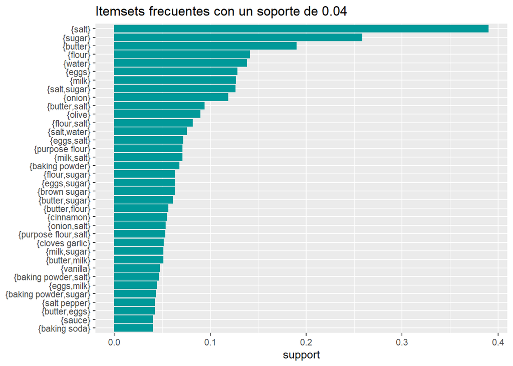

De estos 36, a continuación se identifican aquellos itemsets con un soporte de 0.1:

#### Soporte = 0.1

```r
summary(freqitem3)
```

```
set of 9 itemsets

most frequent items:
   salt   sugar  butter    eggs   flour (Other)
      2       2       1       1       1       3

element (itemset/transaction) length distribution:sizes
1 2
8 1

   Min. 1st Qu.  Median    Mean 3rd Qu.    Max.
  1.000   1.000   1.000   1.111   1.000   2.000

summary of quality measures:
    support       transIdenticalToItemsets     count
 Min.   :0.1189   Min.   :177.0            Min.   :177.0
 1st Qu.:0.1269   1st Qu.:189.0            1st Qu.:189.0
 Median :0.1383   Median :206.0            Median :206.0
 Mean   :0.1799   Mean   :267.9            Mean   :267.9
 3rd Qu.:0.1901   3rd Qu.:283.0            3rd Qu.:283.0
 Max.   :0.3902   Max.   :581.0            Max.   :581.0

includes transaction ID lists: FALSE

mining info:
 data ntransactions support
 data          1489     0.1
```

En este caso hay sólo 9 items con un soporte de 0.1, 8 de tamaño 1 y 1 de tamaño 2. Es decir, solo los siguientes 9 items/itemset aparecen al menos en el 10% de las recetas del libro de cocina:

```
    items        support   transIdenticalToItemsets count
[1] {salt,sugar} 0.1262592 188                      188
[2] {salt}       0.3901948 581                      581
[3] {sugar}      0.2585628 385                      385
[4] {butter}     0.1900604 283                      283
[5] {water}      0.1383479 206                      206
[6] {flour}      0.1417058 211                      211
[7] {onion}      0.1188717 177                      177
[8] {eggs}       0.1282740 191                      191
[9] {milk}       0.1269308 189                      189
```

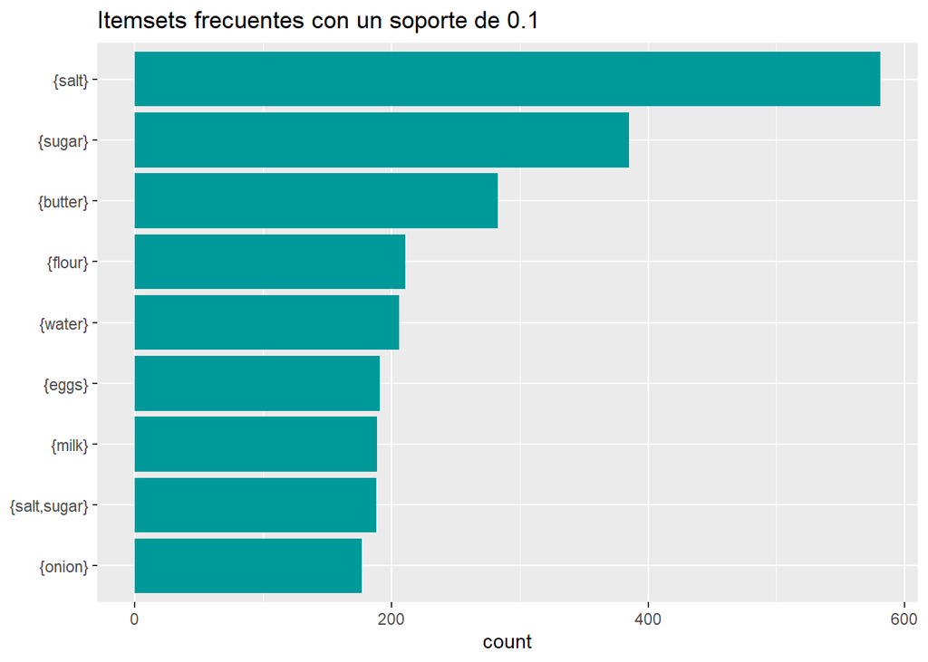

Los ingredientes que figuran en el gráfico están presentes en al menos el 10% de la recetas del libro de cocina. Estos son los ingredientes que más aparecen entre todas las recetas.

# 4. Paso 2: Reglas de asociación

#### Soporte = 0.01 y Confianza = 0.7

```r
AR_1 <- ruleInduction(freqitem1, confidence = .7)
summary(AR_1)
```

```
set of 36 rules

rule length distribution (lhs + rhs):sizes
 2  3  4
 9 20  7

   Min. 1st Qu.  Median    Mean 3rd Qu.    Max.
  2.000   2.750   3.000   2.944   3.000   4.000

summary of quality measures:
    support          confidence          lift
 Min.   :0.01007   Min.   :0.7059   Min.   :1.809
 1st Qu.:0.01142   1st Qu.:0.7353   1st Qu.:2.000
 Median :0.01410   Median :0.7753   Median :2.300
 Mean   :0.01580   Mean   :0.7888   Mean   :2.403
 3rd Qu.:0.01813   3rd Qu.:0.8082   3rd Qu.:2.815
 Max.   :0.05306   Max.   :0.9655   Max.   :3.131
```

Existen 4 reglas redundantes. Se eliminan, y luego se inspeccionan las reglas ordenando según el nivel de confianza.

```r
head(ar1_pruned, 10)
```

```
                               lhs        rhs    support confidence     lift
[18] {baking powder,purpose flour} =>  {salt} 0.01880457  0.9655172 2.474450
[25]          {milk,purpose flour} =>  {salt} 0.01611820  0.9230769 2.365683
[26]          {eggs,purpose flour} =>  {salt} 0.01813298  0.9000000 2.306540
[4]            {bread flour,sugar} =>  {salt} 0.01141706  0.8947368 2.293052
[19]     {baking powder,eggs,milk} =>  {salt} 0.01007388  0.8823529 2.261314
[6]                  {bread flour} =>  {salt} 0.01410343  0.8750000 2.242470
[5]             {bread flour,salt} => {sugar} 0.01141706  0.8095238 3.130860
[12]                {eggs,vanilla} => {sugar} 0.01410343  0.8076923 3.123776
[9]             {sugar,warm water} =>  {salt} 0.01074547  0.8000000 2.050258
[28]         {purpose flour,sugar} =>  {salt} 0.02417730  0.8000000 2.050258
```

Puede verse que la mayor confianza es de 0.965, con un soporte de 0.018. Esto significa que la primera regla se cumple en 28 recetas de las 1489. La primera regla indica que el 96% de las recetas que llevan polvo de hornear y harina también llevan sal.

```r
AR_2 <- ruleInduction(freqitem2, confidence = .5)
summary(AR_2)
```

```
set of 7 rules

rule length distribution (lhs + rhs):sizes
2
7

   Min. 1st Qu.  Median    Mean 3rd Qu.    Max.
      2       2       2       2       2       2

summary of quality measures:
    support          confidence          lift
 Min.   :0.04365   Min.   :0.5485   Min.   :1.406
 1st Qu.:0.05003   1st Qu.:0.5605   1st Qu.:1.437
 Median :0.07119   Median :0.5782   Median :1.482
 Mean   :0.06351   Mean   :0.6185   Mean   :1.705
 3rd Qu.:0.07388   3rd Qu.:0.6683   3rd Qu.:1.843
 Max.   :0.08193   Max.   :0.7453   Max.   :2.489
```

```r
inspect(AR_2)
```

```
    lhs                rhs     support    confidence lift
[1] {baking powder} => {salt}  0.04701142 0.6930693  1.776214
[2] {baking powder} => {sugar} 0.04365346 0.6435644  2.489006
[3] {purpose flour} => {salt}  0.05305574 0.7452830  1.910028
[4] {milk}          => {salt}  0.07118872 0.5608466  1.437350
[5] {eggs}          => {salt}  0.07186031 0.5602094  1.435717
[6] {flour}         => {salt}  0.08193418 0.5781991  1.481822
[7] {water}         => {salt}  0.07588986 0.5485437  1.405820
```

Puede verse que sólo hay 7 reglas con un soporte de al menos 0.04 y una confianza de 0.5 o mayor, y que ninguna es redundante. De las mismas, 6 de ellas tienen como consecuente sal y 1 azúcar.

La primera y segunda reglas indican que en el 69% y 64% respectivamente de las recetas que incluyen polvo de hornear, también se incluye la sal y el azúcar, respectivamente. La regla con mayor confianza nos dice que un 74% de las recetas que tienen harina también tienen sal.

# 5. Recetas con pescado

Se analiza a continuación cuáles son los principales ingredientes utilizados en recetas con pescado. Para ello se filtran, en primer lugar, todas las recetas que contengan algún tipo de pescado, para luego buscar itemsets frecuentes y reglas de asociación.

```
    items
[1] {carrots,
     celery,
     frozen peas,
     hard boiled eggs,
     macaroni,
     maui onion,
     milk,
     salad potatoes,
     salt pepper,
     tuna}
[2] {breadcrumbs,
     butter,
     fish steaks,
     milk,
     salt,
     watercress}
[3] {butter print sure,
     fish fillets flat,
     lemon fresh,
     salt table}
[4] {fish fillets,
     fresh herb,
     white wine}
[5] {chopped fresh parsley,
     fresh jalapeno pepper,
     fresh snapper fillet,
     lemon juice,
     manzanillo olives,
     onion,
     salt,
     tabasco sauce,
     tomato juice,
     tomato puree}
[6] {avocado,
     garnish,
     jalapeno pepper strips,
     juice limes,
     marinade,
     olive,
     oregano,
     parsley,
     pimento stuffed green olives finely chopped,
     salt taste,
     scallops,
     serrano peppers,
     small peeled deveined rimp,
     snapper fillets,
     tomato juice,
     tomatoes,
     white onion,
     worcestershire sauce}
```

A continuación se extraen los itemsets frecuentes, con un soporte de 0.05:

```r
summary(freq_fish)
```

```
set of 51 itemsets

most frequent items:
   salt  butter   flour   onion   water (Other)
     11       6       5       4       4      41

element (itemset/transaction) length distribution:sizes
 1  2  3
33 16  2

   Min. 1st Qu.  Median    Mean 3rd Qu.    Max.
  1.000   1.000   1.000   1.392   2.000   3.000

summary of quality measures:
    support        transIdenticalToItemsets     count
 Min.   :0.05660   Min.   : 3.000           Min.   : 3.000
 1st Qu.:0.05660   1st Qu.: 3.000           1st Qu.: 3.000
 Median :0.05660   Median : 3.000           Median : 3.000
 Mean   :0.07954   Mean   : 4.216           Mean   : 4.216
 3rd Qu.:0.08491   3rd Qu.: 4.500           3rd Qu.: 4.500
 Max.   :0.28302   Max.   :15.000           Max.   :15.000

includes transaction ID lists: FALSE

mining info:
          data ntransactions support
 trans_pescado            53    0.05
```

Se han encontrado 51 itemsets frecuentes. Los ingredientes más frecuentes son sal, mantequilla, harina, cebolla y agua.

```
     items                   support    transIdenticalToItemsets count
[1]  {fish sauce,lime juice} 0.05660377  3                        3
[2]  {milk,tuna}             0.05660377  3                        3
[3]  {lemon juice,salt}      0.05660377  3                        3
[4]  {fish stock,salt}       0.05660377  3                        3
[5]  {fish sauce,sugar}      0.05660377  3                        3
[6]  {butter,leaf}           0.05660377  3                        3
[7]  {butter,white wine}     0.05660377  3                        3
[8]  {salt,vegetable}        0.05660377  3                        3
[9]  {flour,parsley}         0.05660377  3                        3
[10] {butter,flour,salt}     0.05660377  3                        3
[11] {flour,salt}            0.05660377  3                        3
[12] {butter,flour}          0.07547170  4                        4
[13] {olive,salt}            0.05660377  3                        3
[14] {onion,salt,water}      0.05660377  3                        3
```

[output cut: 37 more lines]

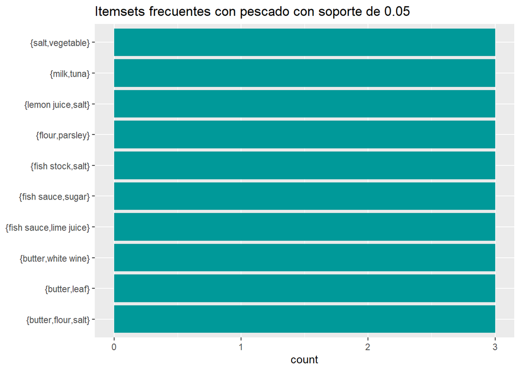

Luego se buscan reglas de asociación con una confianza de 0.5, y se examina si existen reglas redundantes

```r
summary(ar_fish)
```

```
set of 26 rules

rule length distribution (lhs + rhs):sizes
 2  3
20  6

   Min. 1st Qu.  Median    Mean 3rd Qu.    Max.
  2.000   2.000   2.000   2.231   2.000   3.000

summary of quality measures:
    support          confidence          lift
 Min.   :0.05660   Min.   :0.5000   Min.   : 1.767
 1st Qu.:0.05660   1st Qu.:0.6000   1st Qu.: 2.650
 Median :0.05660   Median :0.6125   Median : 3.975
 Mean   :0.06386   Mean   :0.6776   Mean   : 4.512
 3rd Qu.:0.05660   3rd Qu.:0.7500   3rd Qu.: 5.300
 Max.   :0.11321   Max.   :1.0000   Max.   :10.600
```

```r
inspect(head(ar_fish))
```

```
    lhs              rhs          support    confidence lift
[1] {lime juice}  => {fish sauce} 0.05660377 1.00       10.600000
[2] {fish sauce}  => {lime juice} 0.05660377 0.60       10.600000
[3] {tuna}        => {milk}       0.05660377 0.60        6.360000
[4] {milk}        => {tuna}       0.05660377 0.60        6.360000
[5] {lemon juice} => {salt}       0.05660377 0.75        2.650000
[6] {fish stock}  => {salt}       0.05660377 1.00        3.533333
```

Se han generado 26 reglas, ninguna de ellas es redundante.

La primera indica que todas las recetas que llevan jugo de limon también llevan salsa de pescado. En cambio, la segunda regla nos dice que el 60% de las recetas que llevan salsa de pescado incluyen también jugo de limón.

Graficamente:

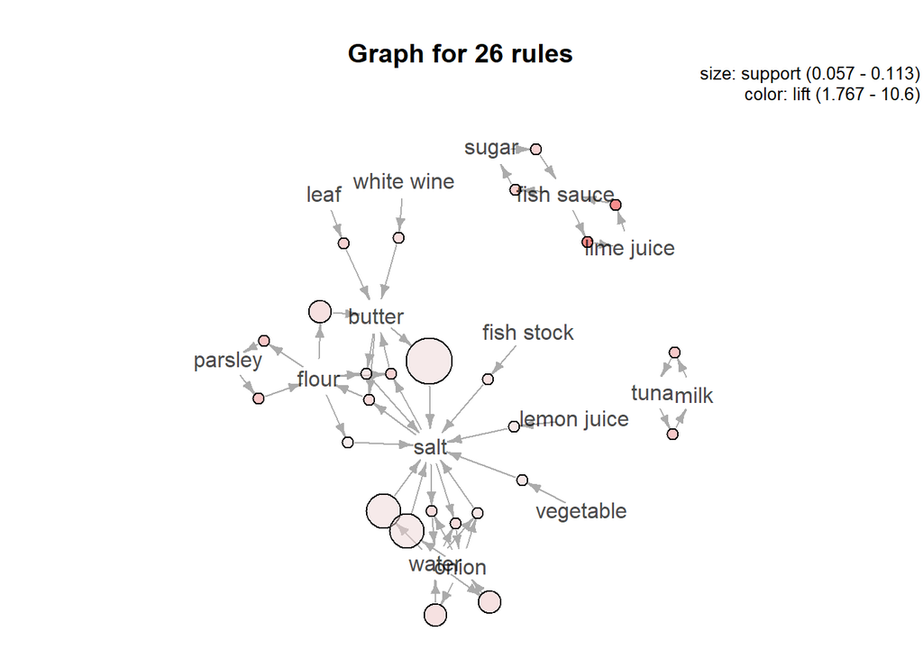

En el gráfico a continuación se observan las reglas según confianza, soporte y lift:

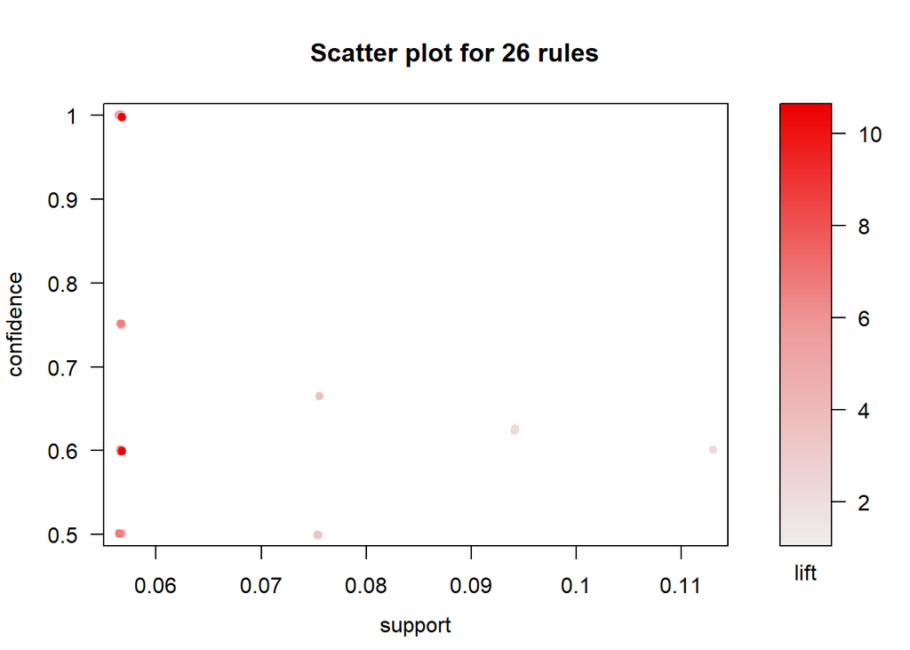

# 6. Análisis extra: eliminación de ingredientes poco relevantes

En esta sección se pretende hacer un análisis de todas las recetas del libro, pero en este caso eliminando ingredientes que no son distintivos, que no son centrales en una receta, y que están presentes en muchas de ellas. Nos referimos, por ejemplo, a la sal y el azúcar, que, como se ha visto, están presentes en muchísimas recetas. Estos dos ingredientes puntualmente, no distinguen a una receta, nisiquiera permiten distinguir si se trata de un plato dulce o salado, puesto que las recetas dulces suelen llevar sal y viceversa.

El procedimiento que se ha realizado es el siguiente: se carga la base de datos con formato transacciones, se observan los ingredientes más frecuentes y si son ingredientes poco relevantes, se eliminan. El proceso continúa hasta que los ingredientes más frecuentes sean “relevantes”.

## 6.1 Eliminación de items poco relevantes

```r
data_clean <- read.table("recetas_limpias_1.csv" , fill = TRUE )
data_clean[data_clean == "salt"] <- ""
data_clean[data_clean == "sugar"] <- ""
data_clean[data_clean == "water"] <- ""
data_clean[data_clean == "fresh"] <- ""
data_clean[data_clean == "ground"] <- ""
data_clean[data_clean == "chopped"] <- ""
data_clean[data_clean == "green"] <- ""
data_clean[data_clean == "black"] <- ""
data_clean[data_clean == "pepper"] <- ""
data_clean[data_clean == "white"] <- ""
data_clean[data_clean == "brown"] <- ""
```

```r
summary(data_no_freq)
```

```
transactions as itemMatrix in sparse format with
 1886 rows (elements/itemsets/transactions) and
 6372 columns (items) and a density of 0.0008101457

most frequent items:
  flour   lemon  garlic chicken  cheese (Other)
    100      70      59      57      51    9399

element (itemset/transaction) length distribution:
sizes
  0   1   2   3   4   5   6   7   8   9
  5 160 196 213 210 223 210 221 249 199

   Min. 1st Qu.  Median    Mean 3rd Qu.    Max.
  0.000   3.000   5.000   5.162   7.000   9.000

includes extended item information - examples:
     labels
1      10lb
2 10lb,salt
3   acrylic
```

```r
data <- data_no_freq
```

## 6.2 Itemsets frecuentes

### Soporte = 0.01

```r
summary(freqitem1)
```

```
set of 36 itemsets

most frequent items:
   beef    bell   bread cheddar  cheese (Other)
      1       1       1       1       1      31

element (itemset/transaction) length distribution:sizes
 1
36

   Min. 1st Qu.  Median    Mean 3rd Qu.    Max.
      1       1       1       1       1       1

summary of quality measures:
    support        transIdenticalToItemsets     count
 Min.   :0.01007   Min.   : 19.00           Min.   : 19.00
 1st Qu.:0.01259   1st Qu.: 23.75           1st Qu.: 23.75
 Median :0.01458   Median : 27.50           Median : 27.50
 Mean   :0.01781   Mean   : 33.58           Mean   : 33.58
 3rd Qu.:0.02028   3rd Qu.: 38.25           3rd Qu.: 38.25
 Max.   :0.05302   Max.   :100.00           Max.   :100.00

includes transaction ID lists: FALSE

mining info:
 data ntransactions support
 data          1886    0.01
```

```r
inspect(head(freqitem1))
```

```
    items     support    transIdenticalToItemsets count
[1] {flour}   0.05302227 100                      100
[2] {lemon}   0.03711559  70                       70
[3] {chicken} 0.03022269  57                       57
[4] {garlic}  0.03128314  59                       59
[5] {cheese}  0.02704136  51                       51
[6] {bell}    0.02226935  42                       42
```

### Soporte = 0.005

```r
freqitem2 <- eclat(data, parameter=list(supp =0.005))
```

```
Eclat

parameter specification:
 tidLists support minlen maxlen            target  ext
    FALSE   0.005      1     10 frequent itemsets TRUE

algorithmic control:
 sparse sort verbose
      7   -2    TRUE

Absolute minimum support count: 9

create itemset ...
set transactions ...[6372 item(s), 1886 transaction(s)] done [0.00s].
sorting and recoding items ... [78 item(s)] done [0.00s].
creating sparse bit matrix ... [78 row(s), 1886 column(s)] done [0.00s].
writing  ... [79 set(s)] done [0.00s].
Creating S4 object  ... done [0.00s].
```

Con un soporte de 0.005 se tienen 79 itemsets frecuentes. Entre los principales ingredientes se tiene chocolate, albahaca y carne de vaca. Hay itemsets de 1 y 2 ingredientes, con 78 y 1 itemsets cada uno.

### Soporte = 0.001

```r
summary(freqitem3)
```

```
set of 1257 itemsets

most frequent items:
chocolate     lemon   chicken     flour  parmesan   (Other)
       28        28        24        23        23      1540

element (itemset/transaction) length distribution:sizes
  1   2   3   4
878 352  24   3

   Min. 1st Qu.  Median    Mean 3rd Qu.    Max.
  1.000   1.000   1.000   1.325   2.000   4.000

summary of quality measures:
    support         transIdenticalToItemsets     count
 Min.   :0.001060   Min.   :  2.000          Min.   :  2.000
 1st Qu.:0.001060   1st Qu.:  2.000          1st Qu.:  2.000
 Median :0.001060   Median :  2.000          Median :  2.000
 Mean   :0.002169   Mean   :  4.091          Mean   :  4.091
 3rd Qu.:0.002121   3rd Qu.:  4.000          3rd Qu.:  4.000
 Max.   :0.053022   Max.   :100.000          Max.   :100.000

includes transaction ID lists: FALSE

mining info:
 data ntransactions support
 data          1886   0.001
```

```r
inspect(head(freqitem3))
```

```
    items                   support transIdenticalToItemsets count
[1] {flour,
     sugar,salt,warm}   0.001060445                        2     2
[2] {parsley,
     zucchini,chopped}  0.001060445                        2     2
[3] {garlic,salt,
     pepper,clove}      0.001060445                        2     2
[4] {flour,sugar,salt,
     machine,
     milk,butter,bread,
     yeast,bread}       0.001060445                        2     2
[5] {flour,sugar,salt,
     machine,
     milk,butter,bread} 0.001060445                        2     2
[6] {flour,sugar,salt,
     milk,butter,bread,
     yeast,bread}       0.001060445                        2     2
```

Con un soporte de 0.001 se tienen 1257 itemsets, de los cuales los más frecuentes son chocolate, limón, pollo, harina y queso parmesano.

## 6.3 Reglas de asociación

Se analizará el set de ingredientes frecuentes con un soporte de 0.001, para tener una base más amplia sobre la cual buscar reglas de asociación. Se han buscado reglas de asociación en los itemsets frecuentes con un soporte de 0.005 pero el algoritmo no ha detectado ninguna. Por lo tanto, se utiliza una confianza de 70%.

### Soporte = 0.001 y Confianza = 0.7

```r
summary(AR_1)
```

```
set of 142 rules

rule length distribution (lhs + rhs):sizes
 2  3  4
84 47 11

   Min. 1st Qu.  Median    Mean 3rd Qu.    Max.
  2.000   2.000   2.000   2.486   3.000   4.000

summary of quality measures:
    support           confidence          lift
 Min.   :0.001060   Min.   :0.7500   Min.   : 15.09
 1st Qu.:0.001060   1st Qu.:1.0000   1st Qu.: 49.97
 Median :0.001060   Median :1.0000   Median :107.86
 Mean   :0.001206   Mean   :0.9816   Mean   :238.50
 3rd Qu.:0.001060   3rd Qu.:1.0000   3rd Qu.:471.50
 Max.   :0.003181   Max.   :1.0000   Max.   :943.00
```

```r
inspect(head(AR_1))
```

```
    lhs                    rhs                     support confidence      lift
[1] {sugar,salt,warm}   => {flour}             0.001060445          1  18.86000
[2] {zucchini,chopped}  => {parsley}           0.001060445          1  69.85185
[3] {pepper,clove}      => {garlic,salt}       0.001060445          1 188.60000
[4] {machine,
     milk,butter,bread,
     yeast,bread}       => {flour,sugar,salt}  0.001060445          1 471.50000
[5] {flour,sugar,salt,
     milk,butter,bread,
     yeast,bread}       => {machine}           0.001060445          1 471.50000
[6] {flour,sugar,salt,
     machine,
     yeast,bread}       => {milk,butter,bread} 0.001060445          1 943.00000
```

Se han detectado 39 reglas redundates.

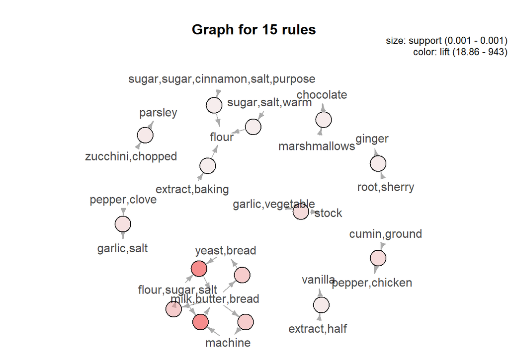

Resulta interesante observar cómo cambian tanto los itemsets frecuentes como las reglas de asociación cuando se quitan ingredientes poco relevantes.